# Statistics

## Overview

We will cover how to use R to compute some of basic statistics and fit some basic statistical models.

- Correlation
- T-test
- Linear Regression
- Logistic Regression

**DISCLAIMER**: We will focus on how to use R software to do these. We will be glossing over the statistical theory and “formulas” for these tests. Moreover, we do not claim the data we use for demonstration meet assumptions of the methods.

There are plenty of resources online for learning more about these methods, as well as dedicated Biostatistics series (at different advancement levels) at the JHU School of Public Health.

## Correlation

## Correlation

Function `cor()` computes correlation in R

```
cor(x, y = NULL, use = "everything",
    method = c("pearson", "kendall", "spearman"))
```

To use:

- provide two numeric vectors (arguments `x`, `y`) to compute correlation between them, or
- provide matrix or data frame (argument `x`) that has at least 2 columns (must be numeric) to compute correlation between all pairs

By default, Pearson correlation coefficient is computed.

## Correlation

https://jhudatascience.org/intro_to_R_class/data/Charm_City_Circulator_Ridership.csv

```r
circ <- jhur::read_circulator()
head(circ)
```

```
# A tibble: 6 x 15
  day     date    orangeBoardings orangeAlightings orangeAverage purpleBoardings
  <chr>   <chr>             <dbl>            <dbl>         <dbl>           <dbl>
1 Monday  01/11/…             877             1027          952               NA
2 Tuesday 01/12/…             777              815          796               NA
3 Wednes… 01/13/…            1203             1220         1212.              NA
4 Thursd… 01/14/…            1194             1233         1214.              NA
5 Friday  01/15/…            1645             1643         1644               NA
6 Saturd… 01/16/…            1457             1524         1490.              NA
# … with 9 more variables: purpleAlightings <dbl>, purpleAverage <dbl>,
#   greenBoardings <dbl>, greenAlightings <dbl>, greenAverage <dbl>,
#   bannerBoardings <dbl>, bannerAlightings <dbl>, bannerAverage <dbl>,
#   daily <dbl>
```

## Correlation for two vectors

First, we compute correlation by providing two vectors.

Like other functions, if there are `NA`s, you get `NA` as the result. But if you specify use only the complete observations, then it will give you correlation using the non-missing data.

```r
x <- pull(circ, orangeAverage)
y <- pull(circ, purpleAverage)
```

```r
cor(x, y)
```

```
[1] NA
```

```r
cor(x, y, use = "complete.obs")
```

```
[1] 0.9195356
```

## Correlation for two vectors with plot

Note that you can add the correlation value to a plot, via the `annotate()`.

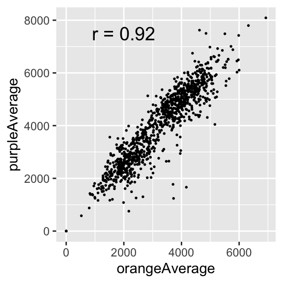

```r
cor_val <- cor(x, y, use = "complete.obs")
cor_val_label <- paste0("r = ", round(cor_val, 3))

circ %>%
  ggplot(aes(x = orangeAverage, y = purpleAverage)) +
  geom_point(size = 0.3) +
  annotate("text", x = 2000, y = 7500, label = cor_val_label, size = 5)
```

## Correlation for data frame columns

We can compute correlation for all pairs of columns of a data frame / matrix. We typically just say, *“compute correlation matrix”*.

Columns must be all numeric!

```r
circ_subset_Average <- circ %>% select(ends_with("Average"))
dim(circ_subset_Average)
```

```
[1] 1146    4
```

```r
cor_mat <- cor(circ_subset_Average, use = "complete.obs")
cor_mat
```

```
              orangeAverage purpleAverage greenAverage bannerAverage
orangeAverage     1.0000000     0.9078826    0.8395806     0.5447031
purpleAverage     0.9078826     1.0000000    0.8665630     0.5213462
greenAverage      0.8395806     0.8665630    1.0000000     0.4533421
bannerAverage     0.5447031     0.5213462    0.4533421     1.0000000
```

## Correlation for data frame columns with plot

- Google, *“r correlation matrix plot”*

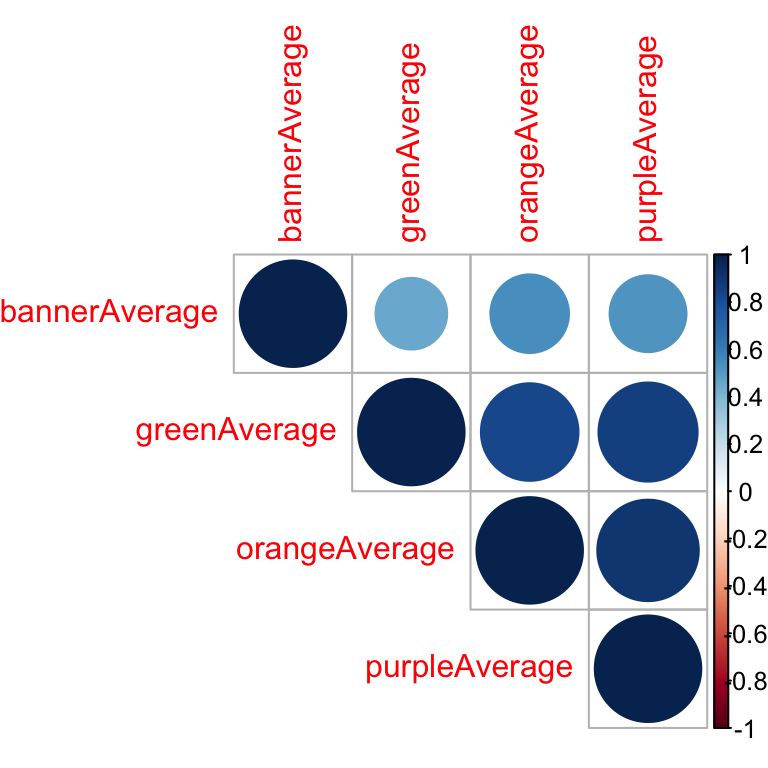

```r
library(corrplot)
corrplot(cor_mat, type = "upper", order = "hclust")
```

## Lab Part 1

[Website](http://jhudatascience.org/intro_to_R_class/index.html)

## T-test

## T-test

The commonly used are:

- **one-sample t-test** – used to test mean of a variable in one group
- **two-sample t-test** – used to test difference in means of a variable between two groups (if the “two groups” are data of the *same* individuals collected at 2 time points, we say it is two-sample paired t-test)

The `t.test()` function in R is one to address the above.

```
t.test(x, y = NULL,
       alternative = c("two.sided", "less", "greater"),
       mu = 0, paired = FALSE, var.equal = FALSE,
       conf.level = 0.95, ...)
```

## Running one-sample t-test

It tests mean of a variable in one group. By default (i.e., without us explicitly specifying values of other arguments):

- tests whether a mean of a variable is equal to 0 (`mu=0`)
- uses “two sided” alternative (`alternative = "two.sided"`)
- returns result assuming confidence level 0.95 (`conf.level = 0.95`)

```r
x <- pull(circ, orangeAverage)
t.test(x)
```

```
    One Sample t-test

data:  x
t = 83.279, df = 1135, p-value < 0.00000000000000022
alternative hypothesis: true mean is not equal to 0
95 percent confidence interval:
 2961.700 3104.622
sample estimates:
mean of x
 3033.161
```

## Running two-sample t-test

It tests test difference in means of a variable between two groups. By default:

- tests whether difference in means of a variable is equal to 0 (`mu=0`)
- uses “two sided” alternative (`alternative = "two.sided"`)
- returns result assuming confidence level 0.95 (`conf.level = 0.95`)
- assumes data are not paired (`paired = FALSE`)
- assumes true variance in the two groups is not equal (`var.equal = FALSE`)

```r
x <- pull(circ, orangeAverage)
y <- pull(circ, purpleAverage)
t.test(x, y)
```

```
    Welch Two Sample t-test

data:  x and y
t = -17.076, df = 1984, p-value < 0.00000000000000022
alternative hypothesis: true difference in means is not equal to 0
95 percent confidence interval:
 -1096.7602  -870.7867
sample estimates:
mean of x mean of y
 3033.161  4016.935
```

## T-test: retrieving information from the result

Object returned from `t.test()` function is a named list. We can use it to access test result elements. The easiest way to do this is to use base R (`$` notation).

```r
result <- t.test(x, y)
is.list(result)
```

```
[1] TRUE
```

```r
names(result)
```

```
 [1] "statistic"   "parameter"   "p.value"     "conf.int"    "estimate"
 [6] "null.value"  "stderr"      "alternative" "method"      "data.name"
```

```r
result$statistic
```

```
        t
-17.07579
```

```r
result$p.value
```

```
[1] 0.0000000000000000000000000000000000000000000000000000000000004201155
```

## T-test: retrieving information from the result with `broom` package

The `broom` package has a `tidy()` function that can organize results into a data frame so that they are easily manipulated (or nicely printed)

```r
library(broom)

result <- t.test(x, y)
result_tidy <- tidy(result)
result_tidy
```

```
# A tibble: 1 x 10
  estimate estimate1 estimate2 statistic  p.value parameter conf.low conf.high
     <dbl>     <dbl>     <dbl>     <dbl>    <dbl>     <dbl>    <dbl>     <dbl>
1    -984.     3033.     4017.     -17.1 4.20e-61     1984.   -1097.     -871.
# … with 2 more variables: method <chr>, alternative <chr>
```

## Some other statistical tests

- `wilcox.test()` – Wilcoxon signed rank test, Wilcoxon rank sum test
- `shapiro.test()` – Shapiro test
- `ks.test()` – Kolmogorov-Smirnov test
- `var.test()`– Fisher’s F-Test
- `chisq.test()` – Chi-squared test

## Lab Part 2

[Website](http://jhudatascience.org/intro_to_R_class/index.html)

## Regression

## Linear regression

Linear regression is a method to model the relationship between a response and one or more explanatory variables.

We provide a little notation here so some of the commands are easier to put in the proper context.

\[ y_i = \alpha + \beta x_{i} + \varepsilon_i \] where:

- \(y_i\) is the outcome for person i
- \(\alpha\) is the intercept
- \(\beta\) is the slope
- \(x_i\) is the predictor for person i
- \(\varepsilon_i\) is the residual variation for person i

## Linear regression

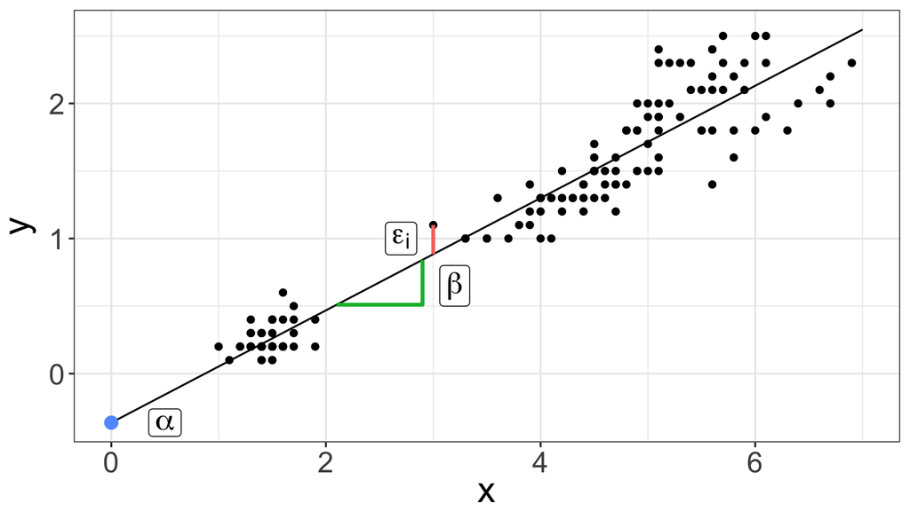

## Linear regression

Linear regression is a method to model the relationship between a response and one or more explanatory variables.

We provide a little notation here so some of the commands are easier to put in the proper context.

\[ y_i = \alpha + \beta_1 x_{i1} + \beta_2 x_{i2} + \beta_3 x_{i3} + \varepsilon_i \] where:

- \(y_i\) is the outcome for person i
- \(\alpha\) is the intercept
- \(\beta_1\), \(\beta_2\), \(\beta_2\) are the slopes for variables \(x_{i1}\), \(x_{i2}\), \(x_{i3}\)
- \(x_{i1}\), \(x_{i2}\), \(x_{i3}\) are the predictors for person i
- \(\varepsilon_i\) is the residual variation for person i

## Linear regression fit in R

To fit linear models in R, we use function `lm()`.

```
lm(formula, data, subset, weights, na.action,
   method = "qr", model = TRUE, x = FALSE, y = FALSE, qr = TRUE,
   singular.ok = TRUE, contrasts = NULL, offset, ...)
```

We typically provide two arguments:

- `formula` – model formula written using names of columns in our data
- `data` – our data frame

## Linear regression fit in R: model formula

Model formula \[ y_i = \alpha + \beta x_{i} + \varepsilon_i \] translates to `y ~ x` in R formula for this example.

In practice, `y` and `x` are replaced with the **names of columns from our data set**.

- For example, if we want to fit a regression model where outcome is `income` and predictor is `years_of_education`, our formula would be:

  `income ~ years_of_education`

## Linear regression fit in R: model formula

Model formula \[ y_i = \alpha + \beta_1 x_{i1} + \beta_2 x_{i2} + \beta_3 x_{i3} + \varepsilon_i \] translates to `y ~ x1 + x2 + x3` in R formula for this example.

In practice, `y` and `x1`, `x2`, `x3` are replaced with the **names of columns from our data set**.

- For example, if we want to fit a regression model where outcome is `income` and predictors are `years_of_education`, `age`, `location` then our formula would be:

  `income ~ years_of_education + age + location`

## Linear regression

We will use `kaggleCarAuction.csv` dataset from one of the Kaggle competitions.

https://jhudatascience.org/intro_to_R_class/data/kaggleCarAuction.csv

```r
cars <- jhur::read_kaggle()
head(cars)
```

```
# A tibble: 6 x 34
  RefId IsBadBuy PurchDate Auction VehYear VehicleAge Make  Model Trim  SubModel
  <dbl>    <dbl> <chr>     <chr>     <dbl>      <dbl> <chr> <chr> <chr> <chr>
1     1        0 12/7/2009 ADESA      2006          3 MAZDA MAZD… i     4D SEDA…
2     2        0 12/7/2009 ADESA      2004          5 DODGE 1500… ST    QUAD CA…
3     3        0 12/7/2009 ADESA      2005          4 DODGE STRA… SXT   4D SEDA…
4     4        0 12/7/2009 ADESA      2004          5 DODGE NEON  SXT   4D SEDAN
5     5        0 12/7/2009 ADESA      2005          4 FORD  FOCUS ZX3   2D COUP…
6     6        0 12/7/2009 ADESA      2004          5 MITS… GALA… ES    4D SEDA…
# … with 24 more variables: Color <chr>, Transmission <chr>, WheelTypeID <chr>,
#   WheelType <chr>, VehOdo <dbl>, Nationality <chr>, Size <chr>,
#   TopThreeAmericanName <chr>, MMRAcquisitionAuctionAveragePrice <chr>,
#   MMRAcquisitionAuctionCleanPrice <chr>,
#   MMRAcquisitionRetailAveragePrice <chr>,
#   MMRAcquisitonRetailCleanPrice <chr>, MMRCurrentAuctionAveragePrice <chr>,
#   MMRCurrentAuctionCleanPrice <chr>, MMRCurrentRetailAveragePrice <chr>,
#   MMRCurrentRetailCleanPrice <chr>, PRIMEUNIT <chr>, AUCGUART <chr>,
#   BYRNO <dbl>, VNZIP1 <dbl>, VNST <chr>, VehBCost <dbl>, IsOnlineSale <dbl>,
#   WarrantyCost <dbl>
```

## Linear regression: model fitting

We fit linear regression model with vehicles odometer (distance traveled by a vehicle; `VehOdo`) as an outcome and vehicle (`VehicleAge`) age as a predictor.

```r
fit <- lm(VehOdo ~ VehicleAge, data = cars)
print(fit)
```

```
Call:
lm(formula = VehOdo ~ VehicleAge, data = cars)

Coefficients:
(Intercept)   VehicleAge
      60127         2723
```

## Linear regression: model summary

The `summary()` command returns a list that shows us some more detail

```r
sfit <- summary(fit)
print(sfit)
```

```
Call:
lm(formula = VehOdo ~ VehicleAge, data = cars)

Residuals:
   Min     1Q Median     3Q    Max
-71097  -9500   1383  10323  41037

Coefficients:
            Estimate Std. Error t value            Pr(>|t|)
(Intercept) 60127.24     134.80  446.04 <0.0000000000000002 ***
VehicleAge   2722.94      29.86   91.18 <0.0000000000000002 ***
---
Signif. codes:  0 '***' 0.001 '**' 0.01 '*' 0.05 '.' 0.1 ' ' 1

Residual standard error: 13810 on 72981 degrees of freedom
Multiple R-squared:  0.1023,    Adjusted R-squared:  0.1023
F-statistic:  8314 on 1 and 72981 DF,  p-value: < 0.00000000000000022
```

## Linear regression: retrieving information with `broom` package

Use `tidy` to create a tibble with the coefficient estimates.

```r
# tidy() is a function from the broom package
tidy(sfit)
```

```
# A tibble: 2 x 5
  term        estimate std.error statistic p.value
  <chr>          <dbl>     <dbl>     <dbl>   <dbl>
1 (Intercept)   60127.     135.      446.        0
2 VehicleAge     2723.      29.9      91.2       0
```

## Linear regression: model summary

Model summary is a named list and we can access its specific elements. Again, we should use base R (`$` notation).

```r
names(sfit)
```

```
 [1] "call"          "terms"         "residuals"     "coefficients"
 [5] "aliased"       "sigma"         "df"            "r.squared"
 [9] "adj.r.squared" "fstatistic"    "cov.unscaled"
```

```r
sfit$r.squared
```

```
[1] 0.1022682
```

## Linear regression: multiple predictors

Let’s try adding another explanatory variable to our model, Warranty price (`WarrantyCost`)

```r
fit_2 <- lm(VehOdo ~ VehicleAge + WarrantyCost, data = cars)
summary(fit_2)
```

```
Call:
lm(formula = VehOdo ~ VehicleAge + WarrantyCost, data = cars)

Residuals:
   Min     1Q Median     3Q    Max
-67895  -8673    940   9305  45765

Coefficients:
                Estimate  Std. Error t value            Pr(>|t|)
(Intercept)  52422.92491   145.98775  359.09 <0.0000000000000002 ***
VehicleAge    1944.65509    28.85619   67.39 <0.0000000000000002 ***
WarrantyCost     8.58147     0.08251  104.01 <0.0000000000000002 ***
---
Signif. codes:  0 '***' 0.001 '**' 0.01 '*' 0.05 '.' 0.1 ' ' 1

Residual standard error: 12890 on 72980 degrees of freedom
Multiple R-squared:  0.2182,    Adjusted R-squared:  0.2181
F-statistic: 1.018e+04 on 2 and 72980 DF,  p-value: < 0.00000000000000022
```

## Linear regression: factors

Factors get special treatment in regression models - lowest level of the factor is the comparison group, and all other factors are relative to its values.

`TopThreeAmericanName` states if the manufacturer is one of the top three American manufacturers.

```r
top_3 <- pull(cars, TopThreeAmericanName)
table(top_3)
```

```
top_3
CHRYSLER     FORD       GM     NULL    OTHER
   23399    12315    25314        5    11950
```

## Linear regression: factors

```r
fit_3 <- lm(VehOdo ~ factor(TopThreeAmericanName), data = cars)
summary(fit_3)
```

```
Call:
lm(formula = VehOdo ~ factor(TopThreeAmericanName), data = cars)

Residuals:
   Min     1Q Median     3Q    Max
-71947  -9634   1532  10472  45936

Coefficients:
                                  Estimate Std. Error t value
(Intercept)                       68248.48      92.98 733.984
factor(TopThreeAmericanName)FORD   8523.49     158.35  53.828
factor(TopThreeAmericanName)GM     4952.18     128.99  38.393
factor(TopThreeAmericanName)NULL  -2004.68    6361.60  -0.315
factor(TopThreeAmericanName)OTHER   584.87     159.92   3.657
                                              Pr(>|t|)
(Intercept)                       < 0.0000000000000002 ***
factor(TopThreeAmericanName)FORD  < 0.0000000000000002 ***
factor(TopThreeAmericanName)GM    < 0.0000000000000002 ***
factor(TopThreeAmericanName)NULL              0.752670
factor(TopThreeAmericanName)OTHER             0.000255 ***
---
Signif. codes:  0 '***' 0.001 '**' 0.01 '*' 0.05 '.' 0.1 ' ' 1

Residual standard error: 14220 on 72978 degrees of freedom
Multiple R-squared:  0.04822,   Adjusted R-squared:  0.04817
F-statistic: 924.3 on 4 and 72978 DF,  p-value: < 0.00000000000000022
```

## Linear regression: retrieving information with `broom` package

```r
tidy(fit_3)
```

```
# A tibble: 5 x 5
  term                              estimate std.error statistic   p.value
  <chr>                                <dbl>     <dbl>     <dbl>     <dbl>
1 (Intercept)                         68248.      93.0   734.    0
2 factor(TopThreeAmericanName)FORD     8523.     158.     53.8   0
3 factor(TopThreeAmericanName)GM       4952.     129.     38.4   2.74e-319
4 factor(TopThreeAmericanName)NULL    -2005.    6362.     -0.315 7.53e-  1
5 factor(TopThreeAmericanName)OTHER     585.     160.      3.66  2.55e-  4
```

## Generalized Linear Models (GLMs)

Generalized Linear Models (GLMs) allow for fitting regressions for non-continuous/normal outcomes. Examples include: logistic regression, Poisson regression.

We fit GLM with a `glm()` function that has a very similar syntax to the `lm()` function.

The primary difference is in `glm()`, we additionally specify the `family` argument – a description of the error distribution and link function to be used in the model. These include:

- `binomial(link = "logit")`
- `poisson(link = "log")`, and other.

See `?family` documentation for details of family functions.

## Logistic regression

`IsBadBuy` is a 0/1-valued variable stating “if the kicked vehicle was an avoidable purchase”.

```r
glm_fit <- glm(IsBadBuy ~ VehOdo + VehicleAge, data = cars, family = binomial())
summary(glm_fit)
```

```
Call:
glm(formula = IsBadBuy ~ VehOdo + VehicleAge, family = binomial(),
    data = cars)

Deviance Residuals:
    Min       1Q   Median       3Q      Max
-0.9943  -0.5481  -0.4534  -0.3783   2.6318

Coefficients:
                 Estimate    Std. Error z value            Pr(>|z|)
(Intercept) -3.7782285193  0.0638091954 -59.211 <0.0000000000000002 ***
VehOdo       0.0000083410  0.0000008526   9.783 <0.0000000000000002 ***
VehicleAge   0.2681085873  0.0067722363  39.589 <0.0000000000000002 ***
---
Signif. codes:  0 '***' 0.001 '**' 0.01 '*' 0.05 '.' 0.1 ' ' 1

(Dispersion parameter for binomial family taken to be 1)

    Null deviance: 54421  on 72982  degrees of freedom
Residual deviance: 52346  on 72980  degrees of freedom
AIC: 52352

Number of Fisher Scoring iterations: 5
```

## Final note

Some final notes:

- Researcher’s responsibility to **understand the statistical method** they use – underlying assumptions, correct interpretation of method results
- Researcher’s responsibility to **understand the R software** they use – meaning of function’s arguments and meaning of function’s output elements

## Lab Part 3

[Website](http://jhudatascience.org/intro_to_R_class/index.html)